# Estymacja i backtesting miar ryzyka rynkowego dla kursu PLN/NOK

Aleksander Potok

2025-11-30

# Wstęp

Analiza została wykonana na dziennych notowaniach kursu walutowego pary PLN/NOK (polski złoty do korony norweskiej). Notowania pochodzą z okresu 04.01.2016 - 10.10.2025 i stanowią próbę ponad 2500 obserwacji. Dane pobrałem ze strony https://stooq.pl. Celem projektu jest wyznaczenie różnymi metodami Value at Risk (VaR) i Expected Shortfall (ES) oraz zweryfikowanie jakości uzyskanych wyników za pomocą testów wstecznych.

```r
library(ggplot2)
library(tidyverse)
library(moments)
library(knitr)
library(patchwork)
library(rugarch)

plnnok_d <- read.csv("plnnok_d.csv")
plnnok_d$Data <- as.Date(plnnok_d$Data)
u = log(plnnok_d[2:2527,5]/plnnok_d[1:2526,5]) * 100
```

Na początku przyjrzymy się wykresowi dziennych notowań oraz logarytmicznych stóp zwrotu.

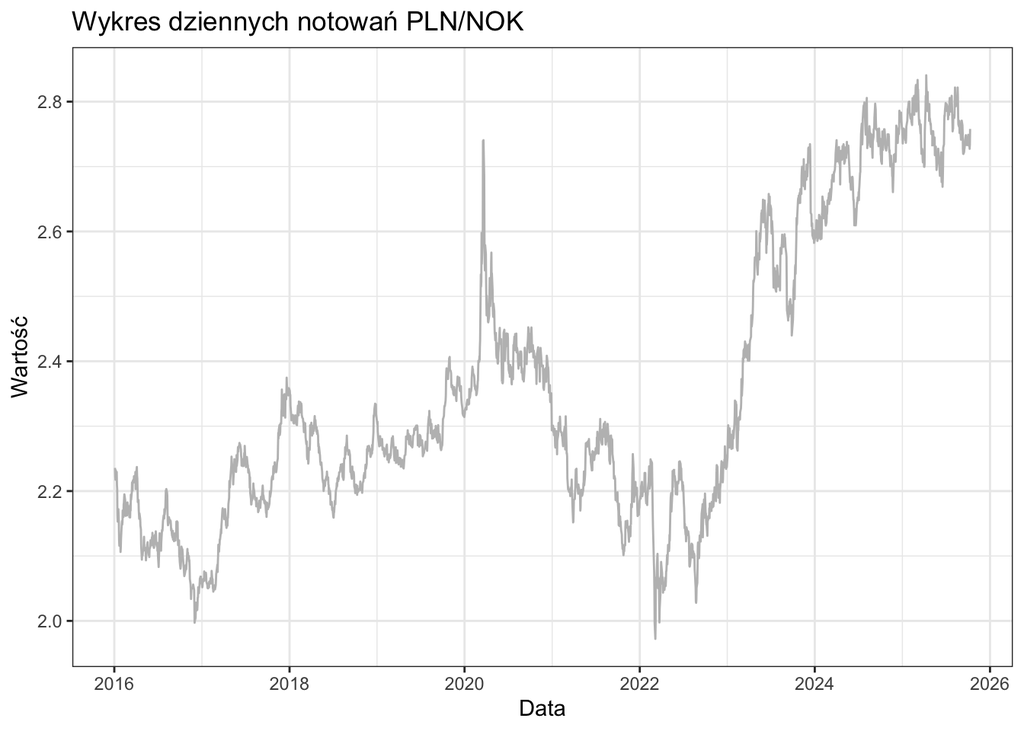

```r
ggplot()+
  geom_line(aes(x=plnnok_d$Data, y=plnnok_d$Zamkniecie), col="grey") +
  labs(
    x = "Data",
    y = "Wartość",
    title = "Wykres dziennych notowań PLN/NOK"
  ) +
  theme_bw()
```

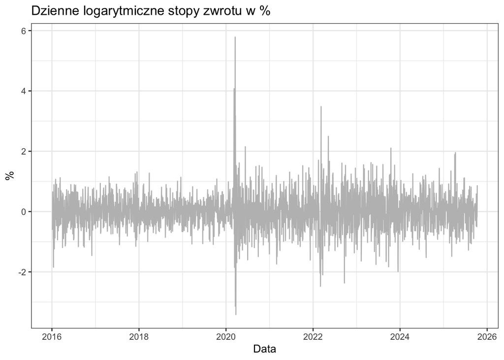

```r
ggplot() +
  geom_line(aes(x = plnnok_d$Data[2:2527], y=u), col="grey") +
  labs(
    x = "Data",
    y = "%",
    title = "Dzienne logarytmiczne stopy zwrotu w %"
  ) +
  theme_bw()
```

W latach 2016-2020 widzimy umiarkowaną tendencję wzrostową kursu. W marcu 2020 roku, po wybuchu pandemii, nastąpił gwałtowny skok notowań, po którym miała miejsce dwuletnia korekta spadkowa. Ostatnie 3 lata to powrót do wyraźnego trendu wzrostowego. Na wykresie logarytmicznych stóp zwrotu najbardziej wyróżnia się efekt pandemii oraz wojny na Ukrainie.

Spójrzmy na statystyki opisowe.

```r
stat_opisowe <- data.frame(
  "Średnia" = mean(u),
  "Odch. stand." = sd(u),
  "Wsp. skośności" = skewness(u),
  "Kurtoza" = moments::kurtosis(u),
  "Min" = min(u),
  "Q1" = quantile(u)[2],
  "Mediana" = median(u),
  "Q3" = quantile(u)[4],
  "Max" = max(u),
  row.names = "Wartość"
)

kable(t(round(stat_opisowe,4)))
```

|  | Wartość |
| --- | --- |
| Średnia | 0.0083 |
| Odch..stand. | 0.5850 |
| Wsp..skośności | 0.4746 |
| Kurtoza | 9.8443 |
| Min | -3.4179 |
| Q1 | -0.3190 |
| Mediana | 0.0167 |
| Q3 | 0.3241 |
| Max | 5.7864 |

Statystyki opisowe są typowe dla logarytmicznych stóp zwrotu. Średnia i mediana są bliskie zera. Odchylenie standardowe jest niewielkie, natomiast kurtoza wynosi 9,84. Oznacza to występowanie “grubych ogonów” - w praktyce ekstremalne stopy zwrotu występują częściej niż przy założeniu o rozkładzie normalnym.

# Value at Risk

Przechodzimy teraz do wyznaczania Value at Risk. We wszystkich przypadkach będziemy wyznaczać VaR i ES 99% na 250-dniowym oknie.

## Metoda historyczna

Pierwszą analizowaną metodą będzie metoda historyczna, która bazuje na empirycznych stratach portfela z ostatnich 250 dni.

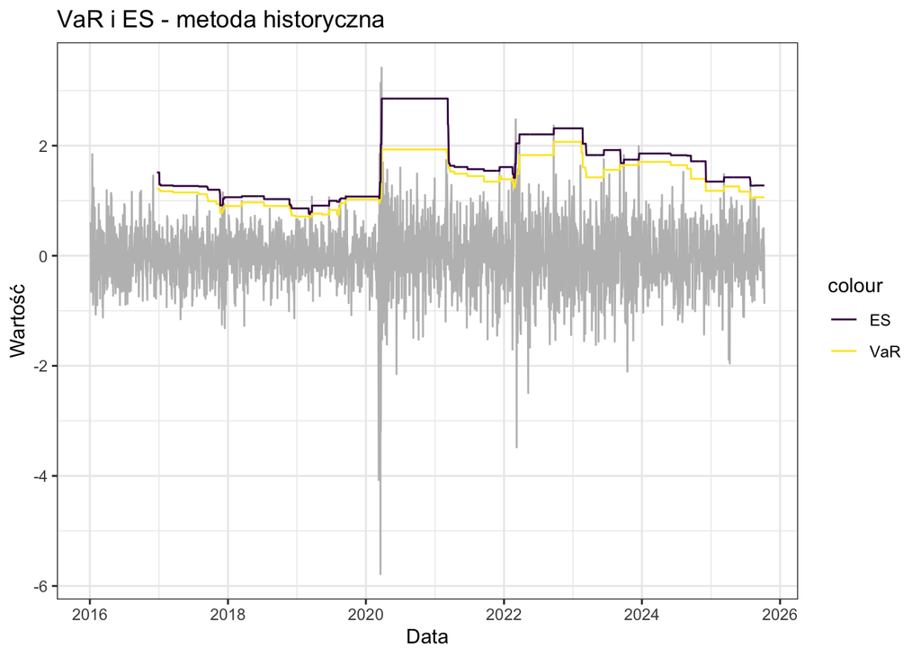

```r
straty <- -u
metoda_historyczna <- function(dane)
{
  n = length(dane)
  VaR <- c()
  ES <- c()

  for(i in 251:n)
  {
    okno <- dane[(i-250):(i-1)]
    VaR[i] <- quantile(okno, 0.99)
    if(VaR[i]<0){
      VaR[i]=0
    }
    ES[i] <- mean(okno[okno>VaR[i]])
  }
  return(list(VaR=VaR, ES=ES))
}

df_metoda_historyczna <- data.frame(
  Data = plnnok_d$Data[2:2527],
  straty = straty,
  VaR_hist = metoda_historyczna(straty)$VaR,
  ES_hist = metoda_historyczna(straty)$ES
)

p_h <- ggplot(data = df_metoda_historyczna, aes(x = Data)) +
  geom_line(aes(y=straty), color = "grey") +
  geom_line(aes(y=VaR_hist, colour = "VaR")) +
  geom_line(aes(y=ES_hist, colour = "ES")) +
  scale_color_viridis_d() +
  labs(
    title = "VaR i ES - metoda historyczna",
    y = "Wartość"
  ) +
  theme_bw()
p_h
```

VaR oszacowany metodą historyczną przybiera postać funkcji schodkowej. Na wykresie widać to najlepiej w 2020 roku, kiedy wysoki skok tuż po wybuchu pandemii “utrzymuje się w pamięci” modelu przez cały rok.

## Metoda historyczna z wagami

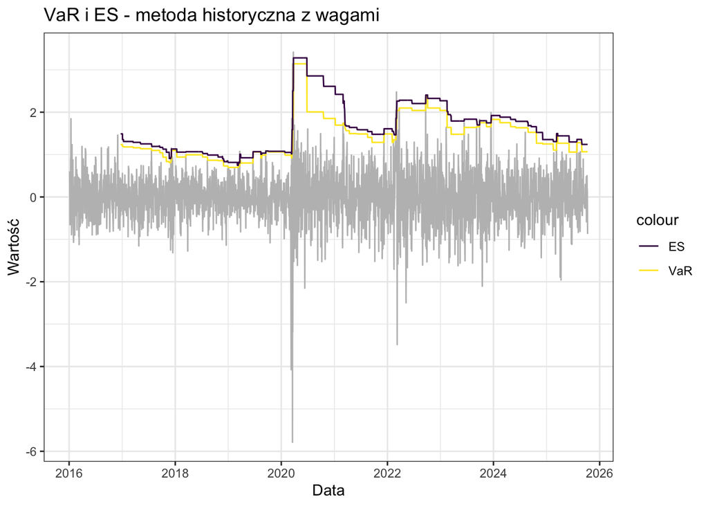

```r
metoda_historyczna_wagi <- function(dane)
{
  n = length(dane)
  VaR <- c()
  ES <- c()
  i <- 1:250
  q <- 0.995

  wagi <- (q^(250-i) * (1-q))/ (1 - q^250)

  for(j in 251:n)
  {
    okno <- dane[(j-250):(j-1)]

    df_okno <- data.frame(
      strata = okno,
      waga = wagi
    ) |>
      arrange(strata) |>
      mutate(skum_wagi = cumsum(waga))

    idx_var <- which(df_okno$skum_wagi >= 0.99)

    VaR[j] <- df_okno$strata[idx_var[1]]
    if(VaR[j]<0){
      VaR[j]=0
    }

    ES[j] <- sum(df_okno$strata[idx_var] * df_okno$waga[idx_var]) / sum(df_okno$waga[idx_var])
  }
  return(list(df_okno = df_okno, VaR=VaR, ES=ES))
}

df_metoda_historyczna_wagi <- data.frame(
  Data = plnnok_d$Data[2:2527],
  straty = straty,
  VaR_wagi = metoda_historyczna_wagi(straty)$VaR,
  ES_wagi = metoda_historyczna_wagi(straty)$ES
)

p_w <- ggplot(data = df_metoda_historyczna_wagi, aes(x = Data)) +
  geom_line(aes(y=straty), color = "grey") +
  geom_line(aes(y=VaR_wagi, colour = "VaR")) +
  geom_line(aes(y=ES_wagi, colour = "ES")) +
  scale_color_viridis_d() +
  labs(
    title = "VaR i ES - metoda historyczna z wagami",
    y = "Wartość"
  ) +
  theme_bw()

p_w
```

Metoda historyczna z wagami jest rozszerzeniem poprzedniej metody. Wagi dla starszych obserwacji są niższe, przez co po dużych skokach jak w 2020 roku, wartość VaR-u szybciej się stabilizuje. Krzywa nadal ma postać funkcji schodkowej, jednak stopnie są zdecydowanie krótsze. Parametr `q`, wpływający na “szybkość zapominania”, przyjąłem równy 0,995.

## Metody parametryczne

Kolejne rozszerzenie oferują metody parametryczne. Odrzucają one założenie o stałości wariancji w czasie.

### EWMA

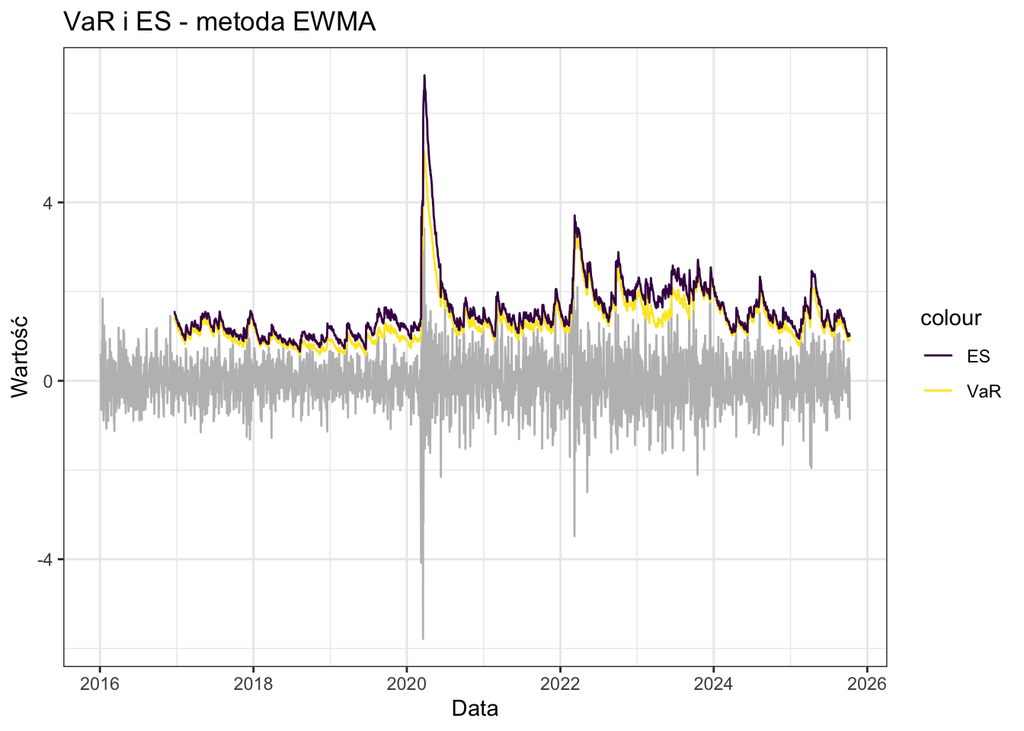

```r
straty <- -u

EWMA <- function(dane, lambda=0.94){
  n = length(dane)
  EWMA <- rep(NA, n)
  EWMA[1] <- var(dane[1:30])
  for (i in 2:n){
    EWMA[i] <- lambda * EWMA[i-1] + (1 - lambda) * dane[i-1]^2
  }
  zm_EWMA <- sqrt(EWMA)
  return(zm_EWMA)
}

metoda_parametryczna_EWMA <- function(dane)
{
  n = length(dane)
  VaR <- c()
  ES <- c()
  zm <- EWMA(dane)

  for(i in 251:n)
  {
    okno <- dane[(i-250):(i-1)]
    zm_n1 <- zm[i]
    okno <- okno * zm_n1 / zm[(i-250):(i-1)]
    VaR[i] <- quantile(okno, 0.99)
    if(VaR[i]<0){
      VaR[i]=0
    }
    ES[i] <- mean(okno[okno>VaR[i]])
  }
  return(list(VaR=VaR, ES=ES))
}

df_metoda_parametryczna_EWMA <- data.frame(
  Data = plnnok_d$Data[2:2527],
  straty = straty,
  VaR_EWMA = metoda_parametryczna_EWMA(straty)$VaR,
  ES_EWMA = metoda_parametryczna_EWMA(straty)$ES
)

p_e <- ggplot(data = df_metoda_parametryczna_EWMA, aes(x = Data)) +
  geom_line(aes(y=straty), color = "grey") +
  geom_line(aes(y=VaR_EWMA, colour = "VaR")) +
  geom_line(aes(y=ES_EWMA, colour = "ES")) +
  scale_color_viridis_d() +
  labs(
    title = "VaR i ES - metoda EWMA",
    y = "Wartość"
  ) +
  theme_bw()
p_e
```

### GARCH(1,1)

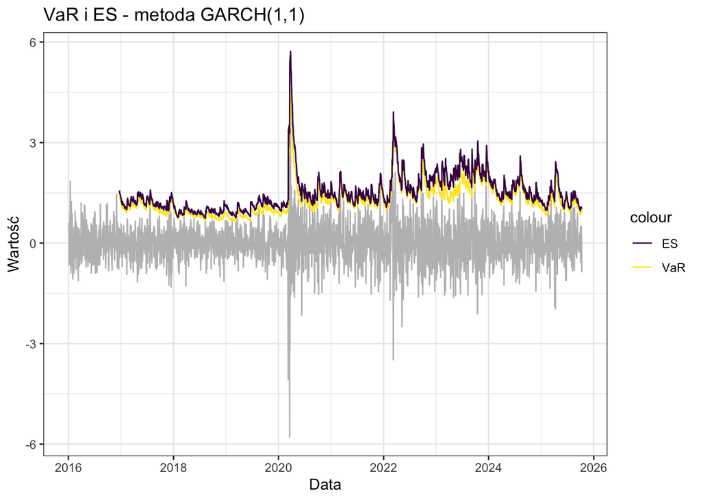

```r
straty <- -u

GARCH <- function(dane){
  n = length(dane)
  garch_spec <- ugarchspec(
    variance.model = list(model = "sGARCH", garchOrder = c(1, 1)),
    mean.model = list(armaOrder = c(0, 0), include.mean = FALSE)
  )
  garch_fit <- ugarchfit(spec = garch_spec, data = dane)
  zm_GARCH <- sigma(garch_fit)
  return(as.vector(zm_GARCH))
}

metoda_parametryczna_GARCH <- function(dane)
{
  n = length(dane)
  VaR <- c()
  ES <- c()
  zm <- GARCH(dane)

  for(i in 251:n)
  {
    okno <- dane[(i-250):(i-1)]
    zm_n1 <- zm[i]
    okno <- okno * zm_n1 / zm[(i-250):(i-1)]
    VaR[i] <- quantile(okno, 0.99)
    if(VaR[i]<0){
      VaR[i]=0
    }
    ES[i] <- mean(okno[okno>VaR[i]])
  }
  return(list(VaR=VaR, ES=ES))
}

df_metoda_parametryczna_GARCH <- data.frame(
  Data = plnnok_d$Data[2:2527],
  straty = straty,
  VaR_G = metoda_parametryczna_GARCH(straty)$VaR,
  ES_G = metoda_parametryczna_GARCH(straty)$ES
)

p_g <- ggplot(data = df_metoda_parametryczna_GARCH, aes(x = Data)) +
  geom_line(aes(y=straty), color = "grey") +
  geom_line(aes(y=VaR_G, colour = "VaR")) +
  geom_line(aes(y=ES_G, colour = "ES")) +
  scale_color_viridis_d() +
  labs(
    title = "VaR i ES - metoda GARCH(1,1)",
    y = "Wartość"
  ) +
  theme_bw()
p_g
```

Obie metody dają zbliżone wyniki. Przede wszystkim metody te szybko reagują na gwałtowne zmiany i wskazują zdecydowanie wyższy VaR niż metody historyczne. Dla skoku po wybuchu pandemii metody EWMA i GARCH(1,1) szacują VaR na poziomie odpowiednio 5,14 i 4,59 - prawie dwa razy wyżej niż poprzednie metody.

## Metoda Monte Carlo

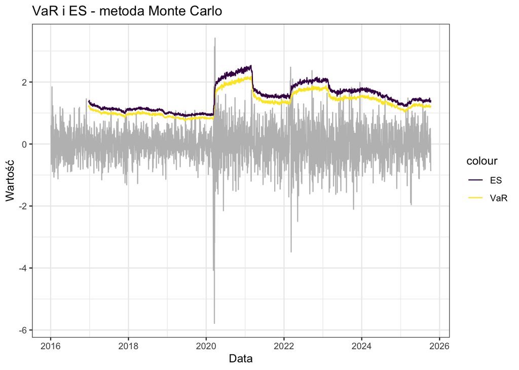

```r
metoda_monte_carlo <- function(dane)
{
  n = length(dane)
  VaR <- c()
  ES <- c()

  for(i in 251:n)
  {
    okno <- dane[(i-250):(i-1)]
    symulacja <- rnorm(10000, mean(okno), sd(okno))
    VaR[i] <- quantile(symulacja, 0.99)
    if(VaR[i]<0){
      VaR[i]=0
    }
    ES[i] <- mean(symulacja[symulacja > VaR[i]])
  }
  return(list(VaR=VaR, ES=ES))
}

df_metoda_monte_carlo <- data.frame(
  Data = plnnok_d$Data[2:2527],
  straty = straty,
  VaR_MC = metoda_monte_carlo(straty)$VaR,
  ES_MC = metoda_monte_carlo(straty)$ES
)

p_mc <- ggplot(data = df_metoda_monte_carlo, aes(x = Data)) +
  geom_line(aes(y=straty), color = "grey") +
  geom_line(aes(y=VaR_MC, colour = "VaR")) +
  geom_line(aes(y=ES_MC, colour = "ES")) +
  scale_color_viridis_d() +
  labs(
    title = "VaR i ES - metoda Monte Carlo",
    y = "Wartość"
  ) +
  theme_bw()
p_mc
```

Metoda Monte Carlo padła ofiarą załozenia o normalności stóp zwrotu. W okresach większej zmienności, tuż po wybuchu pandemii czy wojny w Ukrainie, model reaguje z dużym opóźnieniem na wysokie straty.

## Porównanie

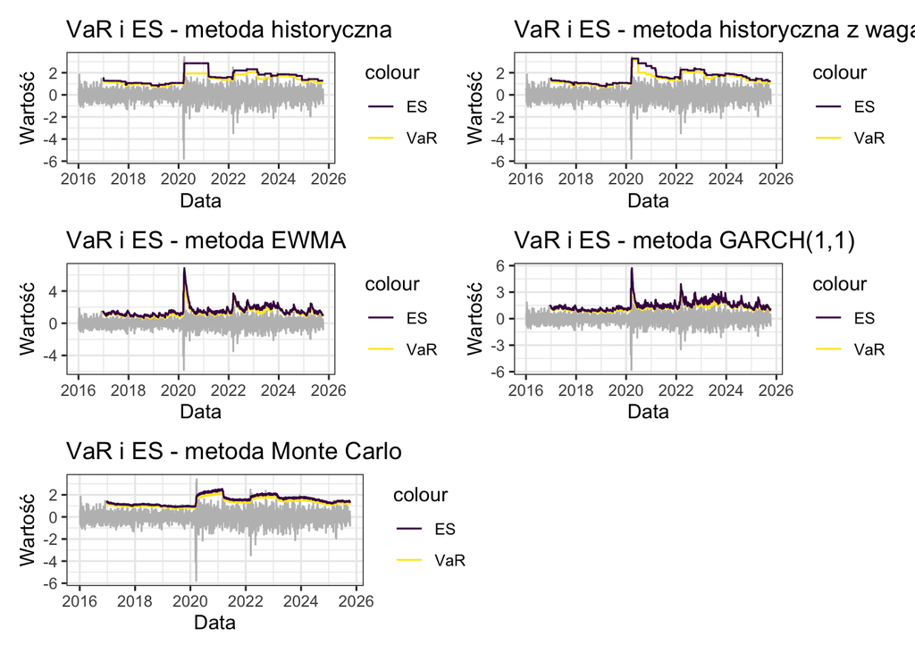

```r
empty <- ggplot() + theme_void()
(p_h + p_w) / (p_e + p_g) / (p_mc + empty)
```

# Testy wsteczne

Zajmiemy się weryfikacją uzyskanych wyników za pomocą testów wstecznych. Łączymy wyniki w jeden data frame i zliczamy wyjątki w oknie 250 obserwacji.

```r
df <- df_metoda_historyczna |>
  select(Data, Strata = straty, VaR_hist) |>
  inner_join(df_metoda_historyczna_wagi |> select(Data, VaR_wagi), by = "Data") |>
  inner_join(df_metoda_parametryczna_EWMA |> select(Data, VaR_EWMA), by = "Data") |>
  inner_join(df_metoda_parametryczna_GARCH |> select(Data, VaR_G), by = "Data") |>
  inner_join(df_metoda_monte_carlo |> select(Data, VaR_MC), by = "Data") |>
  na.omit()
```

```r
zliczenie_wyjatkow <- function(straty, VaR, T=250){
  wyjatki <- c()
  n <- length(straty)
  for(i in (T+1):n){
    okno = straty[(i-T):(i-1)]
    wyjatki[i] <- sum(okno > VaR[i])
  }
  return(wyjatki)
}

wyjatki_wagi <- zliczenie_wyjatkow(df$Strata, df$VaR_wagi)
wyjatki_EWMA <- zliczenie_wyjatkow(df$Strata, df$VaR_EWMA)
wyjatki_GARCH <- zliczenie_wyjatkow(df$Strata, df$VaR_G)
wyjatki_MC <- zliczenie_wyjatkow(df$Strata, df$VaR_MC)
```

## Rozkład liczby wyjątków

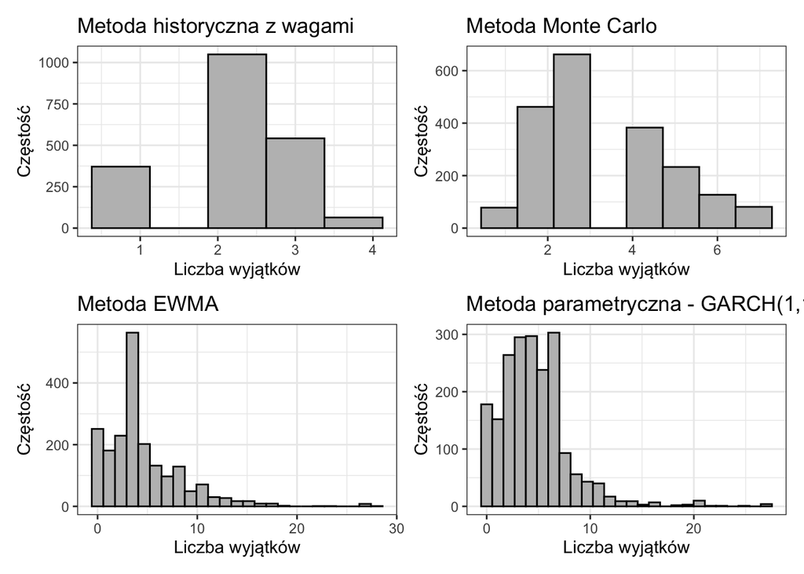

```r
p1 <- ggplot(data.frame(x = wyjatki_wagi), aes(x)) +
  geom_histogram(
    bins = length(unique(wyjatki_wagi)),
    fill = "grey", color = "black") +
  labs(title = "Metoda historyczna z wagami", x = "Liczba wyjątków", y = "Częstość") +
  theme_bw()

p2 <- ggplot(data.frame(x = wyjatki_EWMA), aes(x)) +
  geom_histogram(
    bins = length(unique(wyjatki_EWMA)),
    fill = "grey", color = "black") +
  labs(title = "Metoda EWMA", x = "Liczba wyjątków", y = "Częstość") +
  theme_bw()

p3 <- ggplot(data.frame(x = wyjatki_MC), aes(x)) +
  geom_histogram(
    bins = length(unique(wyjatki_MC)),
    fill = "grey", color = "black") +
  labs(title = "Metoda Monte Carlo", x = "Liczba wyjątków", y = "Częstość") +
  theme_bw()

p4 <- ggplot(data.frame(x = wyjatki_GARCH), aes(x)) +
  geom_histogram(
    bins = length(unique(wyjatki_GARCH)),
    fill = "grey", color = "black") +
  labs(title = "Metoda parametryczna - GARCH(1,1)", x = "Liczba wyjątków", y = "Częstość") +
  theme_bw()

(p1 + p3) / (p2 + p4)
```

Uzyskane histogramy mocno się różnią. Metoda historyczna z wagami dała bardzo bezpieczne wyniki - ani razu nie mieliśmy więcej niż 5 wyjątków w oknie. W metodzie Monte Carlo liczba wyjątków w oknie jest nieznacznie większa. Wyniki różnia się mocno dla metod parametrycznych. Średnia liczba wyjątków nosi około 4,5 a największa liczba wyjątków w oknie wyniosła dla metod EWMA i GARCH(1,1) odpowiednio 28 i 27. Sprawdzimy teraz te wyniki za pomocą testu Bernoulliego, które oparty jest na rozkładzie dwumianowym.

## Test Bernoulliego

Dla okien o długości 250 oraz 100 obserwacji sprawdzamy za pomocą rokzkładu dwumianowego czy liczba wyjątków “wynosi ok. 1%”. Następnie liczymy odsetek przypadków, w których odrzuciliśmy hipotezę zerową, czyli gdy liczba wyjątków jest zbyt duża (lub teoretycznie zbyt mała). W literaturze i w publikacjach dostępnych w internecie dominującym podejściem jest liczenie p-value na całym zbiorze danych ze względu na większą moc testu. Również uwzględnimy to podejście, a także sprawdzimy jak zachowywała się liczba wyjątków w zależności od metody w okresie spokojnym (lata 2017-2019), a jak w latach burzliwych (2020-2022).

```r
rozk_bernoulliego <- function(zliczone_wyjatki, T=250, p = 0.01){
  pvalue = 1 - pbinom(q = zliczone_wyjatki - 1, size = T, prob = p)
  pvalue = na.omit(pvalue)
  return(pvalue)
}
```

```r
wyniki_testy_wsteczne <- function(straty, VaR, daty, metoda){
  wyjatki <- sum(straty > VaR)
  pvalue <- 1 - pbinom(q = wyjatki-1, size = length(straty), prob = 0.01)

  idx_spokojne <- (daty >= "2017-01-01" & daty <= "2019-12-31")
  wyjatki_spokojne <- sum(straty[idx_spokojne] > VaR[idx_spokojne])
  pvalue_spokojne <- 1 - pbinom(q = wyjatki_spokojne-1, size = sum(idx_spokojne), prob = 0.01)

  idx_burzliwe <- (daty >= "2020-01-01" & daty <= "2022-12-31")
  wyjatki_burzliwe <- sum(straty[idx_burzliwe] > VaR[idx_burzliwe])
  pvalue_burzliwe <- 1 - pbinom(q = wyjatki_burzliwe-1, size = sum(idx_burzliwe), prob = 0.01)

  wyjatki_250 <- zliczenie_wyjatkow(straty, VaR, T = 250)
  pvalue_250  <- rozk_bernoulliego(wyjatki_250, T = 250)
  odsetek_250 <- mean(pvalue_250 < 0.05, na.rm = TRUE)

  wyjatki_100 <- zliczenie_wyjatkow(straty, VaR, T = 100)
  pvalue_100  <- rozk_bernoulliego(wyjatki_100, T = 100)
  odsetek_100 <- mean(pvalue_100 < 0.05, na.rm = TRUE)

  return(data.frame(
    Metoda = metoda,
    `Odrzucenia 250` = odsetek_250,
    `Odrzucenia 100` = odsetek_100,
    `pvalue (całość)` = pvalue,
    `pvalue (spokojbe)` = pvalue_spokojne,
    `pvalue (burzliwe)` = pvalue_burzliwe
  ))
}

set.seed(321)
wyniki_b <- rbind(
  wyniki_testy_wsteczne(df$Strata, df$VaR_hist, df$Data, "Historyczna"),
  wyniki_testy_wsteczne(df$Strata, df$VaR_wagi, df$Data, "Wagi"),
  wyniki_testy_wsteczne(df$Strata, df$VaR_EWMA, df$Data, "EWMA"),
    wyniki_testy_wsteczne(df$Strata, df$VaR_G, df$Data, "Garch"),
  wyniki_testy_wsteczne(df$Strata, df$VaR_MC, df$Data, "Monte Carlo")
  )

colnames(wyniki_b) <- c("Metoda", "Odsetek odrzuceń dla okna 250", "Odsetek odrzuceń dla okna 100", "p-value (całość)", "p-value (spokojne)", "p-value (burzliwe)")
kable(wyniki_b, digits = 4)
```

| Metoda | Odsetek odrzuceń dla okna 250 | Odsetek odrzuceń dla okna 100 | p-value (całość) | p-value (spokojne) | p-value (burzliwe) |
| --- | --- | --- | --- | --- | --- |
| Historyczna | 0.0000 | 0.0000 | 0.1586 | 0.2521 | 0.1600 |
| Wagi | 0.0000 | 0.0000 | 0.3460 | 0.5122 | 0.1600 |
| EWMA | 0.2962 | 0.0786 | 0.2742 | 0.5122 | 0.2533 |
| Garch | 0.2971 | 0.0933 | 0.1586 | 0.3724 | 0.1600 |
| Monte Carlo | 0.1027 | 0.0722 | 0.0567 | 0.3724 | 0.0520 |

## Test Christoffersena

Oprócz liczby wyjątków ważnym zjawiskiem jest ich niezależność. Odpowiedź na to dają testy niezależności m.in. test Christoffersena:

$H_0:$ przekroczenia VaR są niezależne w czasie

$H_1:$ przekroczenia VaR nie są niezależne w czasie

```r
christoffersen <- function(straty, VaR, daty, T=250){
  if(T!=0){
    n = length(straty)
    wyniki <- rep(NA, n)
    for(i in (T+1):n){
      okno <- straty[(i-T):(i-1)]
      okno_VaR <- VaR[(i-T):(i-1)]
      wyjatki_bool <- ifelse(okno > okno_VaR, 1, 0)
      u00 <- sum(lag(wyjatki_bool)== 0 & wyjatki_bool == 0, na.rm = T)
      u10 <- sum(lag(wyjatki_bool)== 1 & wyjatki_bool == 0, na.rm = T)
      u01 <- sum(lag(wyjatki_bool)== 0 & wyjatki_bool == 1, na.rm = T)
      u11 <- sum(lag(wyjatki_bool)== 1 & wyjatki_bool == 1, na.rm = T)

      if((u00 + u01 > 0) && (u10 + u11 > 0) && (u00 + u01 + u10 + u11 > 0)) {
        pi <- (u01 + u11)/(u00 + u01 + u10 + u11)
        pi01 <- u01 / (u00 + u01)
        pi11 <- u11 / (u10 + u11)

        z <- -2*log((1-pi)^(u00 + u10)*pi^(u01 + u11)) + 2*log((1-pi01)^u00 * pi01^u01*(1-pi11)^u10*pi11^u11)
        wyniki[i] <- ifelse(z>qchisq(p=0.95, df=1), 1, 0) #1 jeśli
      }
      else{wyniki[i]=0}
    }
  }


  else{
    wyjatki_bool <- ifelse(straty > VaR, 1, 0)
    u00 <- sum(lag(wyjatki_bool)== 0 & wyjatki_bool == 0, na.rm = TRUE)
    u10 <- sum(lag(wyjatki_bool)== 1 & wyjatki_bool == 0, na.rm = TRUE)
    u01 <- sum(lag(wyjatki_bool)== 0 & wyjatki_bool == 1, na.rm = TRUE)
    u11 <- sum(lag(wyjatki_bool)== 1 & wyjatki_bool == 1, na.rm = TRUE)

    if((u00 + u01 > 0) && (u10 + u11 > 0) && (u00 + u01 + u10 + u11 > 0)) {
      pi <- (u01 + u11)/(u00 + u01 + u10 + u11)
      pi01 <- u01 / (u00 + u01)
      pi11 <- u11 / (u10 + u11)

      z <- -2*log((1-pi)^(u00 + u10)*pi^(u01 + u11)) + 2*log((1-pi01)^u00 * pi01^u01*(1-pi11)^u10*pi11^u11)
      wyniki <- 1 - pchisq(z, df=1)
    }
    else{wyniki=1}
  }
  return(wyniki)
}
```

```r
wyniki_testy_niezaleznosci <- function(straty, VaR, daty, metoda){
  pvalue <- christoffersen(straty, VaR, daty, T=0)
  odsetek_250 <- mean(christoffersen(straty, VaR, daty, T=250), na.rm = TRUE)
  odsetek_100 <- mean(christoffersen(straty, VaR, daty, T=100), na.rm = TRUE)

  idx_spokojne <- (daty >= "2017-01-01" & daty <= "2019-12-31")
  pvalue_spokojne <- christoffersen(straty[idx_spokojne], VaR[idx_spokojne], daty[idx_spokojne], T=0)

  idx_burzliwe <- (daty >= "2020-01-01" & daty <= "2022-12-31")
  pvalue_burzliwe <- christoffersen(straty[idx_burzliwe], VaR[idx_burzliwe], daty[idx_burzliwe], T=0)

  return(data.frame(
    Metoda = metoda,
    `Odrzucenia 250` = odsetek_250,
    `Odrzucenia 100` = odsetek_100,
    `pvalue (całość)` = pvalue,
    `pvalue (spokojbe)` = pvalue_spokojne,
    `pvalue (burzliwe)` = pvalue_burzliwe
  ))
}
set.seed(321)
wyniki_c <- rbind(
  wyniki_testy_niezaleznosci(df$Strata, df$VaR_hist, df$Data, "Historyczna"),
  wyniki_testy_niezaleznosci(df$Strata, df$VaR_wagi, df$Data, "Wagi"),
  wyniki_testy_niezaleznosci(df$Strata, df$VaR_EWMA, df$Data, "EWMA"),
  wyniki_testy_niezaleznosci(df$Strata, df$VaR_G, df$Data, "Garch"),
  wyniki_testy_niezaleznosci(df$Strata, df$VaR_MC, df$Data, "Monte Carlo")
  )

colnames(wyniki_c) <- c("Metoda", "Odsetek odrzuceń dla okna 250", "Odsetek odrzuceń dla okna 100","p-value (całość)",  "p-value (spokojne)", "p-value (burzliwe)")
kable(wyniki_c, digits = 4)
```

| Metoda | Odsetek odrzuceń dla okna 250 | Odsetek odrzuceń dla okna 100 | p-value (całość) | p-value (spokojne) | p-value (burzliwe) |
| --- | --- | --- | --- | --- | --- |
| Historyczna | 0.0706 | 0.0014 | 0.0475 | 0.6089 | 0.0074 |
| Wagi | 0.0647 | 0.0014 | 0.2780 | 0.6827 | 0.1414 |
| EWMA | 0.0000 | 0.0000 | 0.4381 | 0.6827 | 0.6091 |
| Garch | 0.0000 | 0.0000 | 0.4035 | 0.6454 | 0.5736 |
| Monte Carlo | 0.2616 | 0.0850 | 0.0000 | 0.6454 | 0.0007 |

# Podsumowanie

Projekt pozwolił na przeanalizowanie pięciu metod liczenia Value at Risk oraz dwóch testów wstecznych - jednego dystrybucyjnego i jednego niezależności. Nie jest możliwe ocenienie, która z metod jest obiektywnie najlepsza. Metoda historyczna oraz historyczna z wagami dawały najbezpiecznejsze wyniki - liczba przekroczeń zawsze była “w normie”. Metody parametryczne dobrze radziły sobie z testem niezależności, poprzez szybkie reagowanie na różnicę w zmienności. Metoda Monte Carlo dała najsłabsze wyniki, ale jest to konsekwencja założenia o rozkładzie normalnym stóp zwrotu.